# Lab 6 Baseball salaries

```python
#packages
import pandas as pd
import numpy as np
from sklearn.pipeline import Pipeline
from sklearn.compose import make_column_selector, ColumnTransformer
from sklearn.preprocessing import StandardScaler, OneHotEncoder, PolynomialFeatures
from sklearn.linear_model import LinearRegression, Ridge, Lasso, ElasticNet
from sklearn.model_selection import train_test_split, cross_val_score
from sklearn.metrics import r2_score
from sklearn.model_selection import GridSearchCV
from plotnine import *
```

# Part 0: Data Cleaning

```python
#import data set
hitters = pd.read_csv("/Users/conniechou/Library/CloudStorage/OneDrive-Personal/Connie/Homework/GSB544_Bodwin/Labs/Hitters.csv")
hitters
```

|  | AtBat | Hits | HmRun | Runs | RBI | Walks | Years | CAtBat | CHits | CHmRun | CRuns | CRBI | CWalks | League | Division | PutOuts | Assists | Errors | Salary | NewLeague |
| --- | --- | --- | --- | --- | --- | --- | --- | --- | --- | --- | --- | --- | --- | --- | --- | --- | --- | --- | --- | --- |
| 0 | 293 | 66 | 1 | 30 | 29 | 14 | 1 | 293 | 66 | 1 | 30 | 29 | 14 | A | E | 446 | 33 | 20 | NaN | A |
| 1 | 315 | 81 | 7 | 24 | 38 | 39 | 14 | 3449 | 835 | 69 | 321 | 414 | 375 | N | W | 632 | 43 | 10 | 475.0 | N |
| 2 | 479 | 130 | 18 | 66 | 72 | 76 | 3 | 1624 | 457 | 63 | 224 | 266 | 263 | A | W | 880 | 82 | 14 | 480.0 | A |
| 3 | 496 | 141 | 20 | 65 | 78 | 37 | 11 | 5628 | 1575 | 225 | 828 | 838 | 354 | N | E | 200 | 11 | 3 | 500.0 | N |
| 4 | 321 | 87 | 10 | 39 | 42 | 30 | 2 | 396 | 101 | 12 | 48 | 46 | 33 | N | E | 805 | 40 | 4 | 91.5 | N |
| ... | ... | ... | ... | ... | ... | ... | ... | ... | ... | ... | ... | ... | ... | ... | ... | ... | ... | ... | ... | ... |
| 317 | 497 | 127 | 7 | 65 | 48 | 37 | 5 | 2703 | 806 | 32 | 379 | 311 | 138 | N | E | 325 | 9 | 3 | 700.0 | N |
| 318 | 492 | 136 | 5 | 76 | 50 | 94 | 12 | 5511 | 1511 | 39 | 897 | 451 | 875 | A | E | 313 | 381 | 20 | 875.0 | A |
| 319 | 475 | 126 | 3 | 61 | 43 | 52 | 6 | 1700 | 433 | 7 | 217 | 93 | 146 | A | W | 37 | 113 | 7 | 385.0 | A |
| 320 | 573 | 144 | 9 | 85 | 60 | 78 | 8 | 3198 | 857 | 97 | 470 | 420 | 332 | A | E | 1314 | 131 | 12 | 960.0 | A |
| 321 | 631 | 170 | 9 | 77 | 44 | 31 | 11 | 4908 | 1457 | 30 | 775 | 357 | 249 | A | W | 408 | 4 | 3 | 1000.0 | A |

322 rows × 20 columns

```python
hitters.dtypes
```

```
AtBat          int64
Hits           int64
HmRun          int64
Runs           int64
RBI            int64
Walks          int64
Years          int64
CAtBat         int64
CHits          int64
CHmRun         int64
CRuns          int64
CRBI           int64
CWalks         int64
League        object
Division      object
PutOuts        int64
Assists        int64
Errors         int64
Salary       float64
NewLeague     object
dtype: object
```

All variable types look ok. Salary (dependent variable) is in float. League, Division, and NewLeague are categorical variables, so they are object type. Everything else is numerical integers.

```python
#drop na values
hitters_df = hitters.dropna()
hitters_df
```

|  | AtBat | Hits | HmRun | Runs | RBI | Walks | Years | CAtBat | CHits | CHmRun | CRuns | CRBI | CWalks | League | Division | PutOuts | Assists | Errors | Salary | NewLeague |
| --- | --- | --- | --- | --- | --- | --- | --- | --- | --- | --- | --- | --- | --- | --- | --- | --- | --- | --- | --- | --- |
| 1 | 315 | 81 | 7 | 24 | 38 | 39 | 14 | 3449 | 835 | 69 | 321 | 414 | 375 | N | W | 632 | 43 | 10 | 475.0 | N |
| 2 | 479 | 130 | 18 | 66 | 72 | 76 | 3 | 1624 | 457 | 63 | 224 | 266 | 263 | A | W | 880 | 82 | 14 | 480.0 | A |
| 3 | 496 | 141 | 20 | 65 | 78 | 37 | 11 | 5628 | 1575 | 225 | 828 | 838 | 354 | N | E | 200 | 11 | 3 | 500.0 | N |
| 4 | 321 | 87 | 10 | 39 | 42 | 30 | 2 | 396 | 101 | 12 | 48 | 46 | 33 | N | E | 805 | 40 | 4 | 91.5 | N |
| 5 | 594 | 169 | 4 | 74 | 51 | 35 | 11 | 4408 | 1133 | 19 | 501 | 336 | 194 | A | W | 282 | 421 | 25 | 750.0 | A |
| ... | ... | ... | ... | ... | ... | ... | ... | ... | ... | ... | ... | ... | ... | ... | ... | ... | ... | ... | ... | ... |
| 317 | 497 | 127 | 7 | 65 | 48 | 37 | 5 | 2703 | 806 | 32 | 379 | 311 | 138 | N | E | 325 | 9 | 3 | 700.0 | N |
| 318 | 492 | 136 | 5 | 76 | 50 | 94 | 12 | 5511 | 1511 | 39 | 897 | 451 | 875 | A | E | 313 | 381 | 20 | 875.0 | A |
| 319 | 475 | 126 | 3 | 61 | 43 | 52 | 6 | 1700 | 433 | 7 | 217 | 93 | 146 | A | W | 37 | 113 | 7 | 385.0 | A |
| 320 | 573 | 144 | 9 | 85 | 60 | 78 | 8 | 3198 | 857 | 97 | 470 | 420 | 332 | A | E | 1314 | 131 | 12 | 960.0 | A |
| 321 | 631 | 170 | 9 | 77 | 44 | 31 | 11 | 4908 | 1457 | 30 | 775 | 357 | 249 | A | W | 408 | 4 | 3 | 1000.0 | A |

263 rows × 20 columns

# Part 1: Different Model Specs

## Regression without regularization

```python
#defining our X and y in global environment because we want to use these for the entire lab
X = hitters_df.drop(["Salary"], axis = 1)
y = hitters_df["Salary"]
```

```python
#function of the general steps for different modeling types
def model(regression_label, type_of_regression):

    """
    transforms columns and outputs a pipeline of the desired kind of regression model

    Parameter
    ---------
    regression_label : str
    A string represeting the label of the modeling type

    type_of_regression: sklearn function
    A specific function for the modeling type

    Returns
    -------
    arrays
    returns the pipeline of the specified type of model
    """

    ct = ColumnTransformer([
    ("dummify",
    OneHotEncoder(sparse_output = False, handle_unknown = "ignore"),
    make_column_selector(dtype_include=object)), #selecting all columns that are categorical
    ("standardize",
    StandardScaler(),
    make_column_selector(dtype_include=np.number)) #standardizing numerical variables
    ], remainder = "passthrough" #keep everything else
    )

    lr_pipeline = Pipeline(
      [("preprocessing", ct),
      (regression_label, type_of_regression)]
    ).set_output(transform = "pandas")

    return lr_pipeline
```

```python
#fitting pipeline onto ENTIRE dataset
pipeline = model(regression_label = "linear_regression", type_of_regression = LinearRegression())
fitted_pipeline = pipeline.fit(X, y)
```

```python
#coefficients for linear model
coeff = fitted_pipeline.named_steps["linear_regression"].coef_
coeff
```

```
array([ -31.29971152,   31.29971152,   58.42462282,  -58.42462282,
         12.38116255,  -12.38116255, -291.0945557 ,  337.83047948,
         37.85383676,  -60.57247861,  -26.99498379,  135.07389695,
        -16.69335888, -391.03865466,   86.68761664,  -14.18172332,
        480.74713477,  260.68988581, -213.89225864,   78.76129639,
         53.73248973,  -22.16086217])
```

```python
#cross validation mse for linear model
cross_val_scores = cross_val_score(pipeline, X, y, cv = 5, scoring = 'neg_mean_squared_error')
-cross_val_scores.mean()
```

```
121136.31031816886
```

### The MSE I would expect to predict 1989 salaries is 121136.3.

```python
#function to find best coefficients
def variable_names_df(pipeline_name, coefficient_list):
    """
    creates a dataframe of the coefficients of the regression and their respective variable names

    Parameter
    ---------
    pipeline_name: variable
    The fitted pipeline variable name

    coefficient_list: array
    An array of the coefficients calculated using .name_steps[].coef_

    Returns
    -------
    pandas data frame
    A data frame with coefficients and their variable names sorted in descending order by coefficients
    """
    feature_names = pipeline_name[:-1].get_feature_names_out()

    coeff_var_df = pd.DataFrame({"variable_name": feature_names,
                                 "coefficients": coefficient_list})
    return coeff_var_df.sort_values(by = "coefficients", ascending = False)
```

```python
#linear regression data frame of coefficients and their variable labels
lr_df = variable_names_df(fitted_pipeline, coeff)
lr_df
```

|  | variable_name | coefficients |
| --- | --- | --- |
| 16 | standardize__CRuns | 480.747135 |
| 7 | standardize__Hits | 337.830479 |
| 17 | standardize__CRBI | 260.689886 |
| 11 | standardize__Walks | 135.073897 |
| 14 | standardize__CHits | 86.687617 |
| 19 | standardize__PutOuts | 78.761296 |
| 2 | dummify__Division_E | 58.424623 |
| 20 | standardize__Assists | 53.732490 |
| 8 | standardize__HmRun | 37.853837 |
| 1 | dummify__League_N | 31.299712 |
| 4 | dummify__NewLeague_A | 12.381163 |
| 5 | dummify__NewLeague_N | -12.381163 |
| 15 | standardize__CHmRun | -14.181723 |
| 12 | standardize__Years | -16.693359 |
| 21 | standardize__Errors | -22.160862 |
| 10 | standardize__RBI | -26.994984 |
| 0 | dummify__League_A | -31.299712 |
| 3 | dummify__Division_W | -58.424623 |
| 9 | standardize__Runs | -60.572479 |
| 18 | standardize__CWalks | -213.892259 |
| 6 | standardize__AtBat | -291.094556 |
| 13 | standardize__CAtBat | -391.038655 |

## Ridge Regression

```python
#creating ridge regression pipeline

pipeline_r = model(regression_label = "ridge_reg", type_of_regression = Ridge())
```

```python
#creating dictionary with different lambda values for tuning
lambdas_list = [0.001, 0.01, 0.1, 1, 10]
lambdas = {'ridge_reg__alpha': lambdas_list}

#running girdsearchcv to tune to different lambda values
gscv = GridSearchCV(pipeline_r, lambdas, cv = 5, scoring='neg_mean_squared_error')
```

```python
#fitting gridsearchcv to entire dataset
gscv_fitted = gscv.fit(X, y)

#creating dataframe for mse values and lambda values
ridge_df = pd.DataFrame(gscv_fitted.cv_results_)
ridge_df = ridge_df[["param_ridge_reg__alpha", "mean_test_score"]] #get the columns i want
ridge_df["mean_test_score"] = ridge_df["mean_test_score"].abs() #absolute value of mean square errors
ridge_df.sort_values(by = "mean_test_score", ascending = True) #sort mse values, want smallest one
```

|  | param_ridge_reg__alpha | mean_test_score |
| --- | --- | --- |
| 3 | 1 | 119144.432677 |
| 4 | 10 | 119348.984776 |
| 2 | 0.1 | 120343.621067 |
| 1 | 0.01 | 121022.903286 |
| 0 | 0.001 | 121124.458592 |

### The model with the lambda value that equals 1 is the best model, since it has the lowest MSE value. The estimated MSE to predict 1989 salaries is 119144.432677.

```python
#fit ridge regression model on entire data set using this lambda = 1
pipeline_r_1 = model(regression_label = "ridge_reg", type_of_regression = Ridge(alpha = 1))
fitted_pipeline_r = pipeline_r_1.fit(X, y)

#coefficients for fitted ridge pipeline
coeff_r = fitted_pipeline_r.named_steps["ridge_reg"].coef_
coeff_r
```

```
array([ -30.43885531,   30.43885531,   60.01559493,  -60.01559493,
         13.11128155,  -13.11128155, -270.6864407 ,  296.64505003,
         18.10059158,  -29.33940613,   -9.11329453,  124.40717273,
        -38.66774782, -225.40654798,  126.65960655,   39.07092364,
        320.41216891,  160.38678418, -184.4236106 ,   78.62365619,
         47.46259711,  -23.72419031])
```

```python
#ridge regression data frame of coefficients and their variable labels
r_df = variable_names_df(fitted_pipeline_r, coeff_r)
r_df
```

|  | variable_name | coefficients |
| --- | --- | --- |
| 16 | standardize__CRuns | 320.412169 |
| 7 | standardize__Hits | 296.645050 |
| 17 | standardize__CRBI | 160.386784 |
| 14 | standardize__CHits | 126.659607 |
| 11 | standardize__Walks | 124.407173 |
| 19 | standardize__PutOuts | 78.623656 |
| 2 | dummify__Division_E | 60.015595 |
| 20 | standardize__Assists | 47.462597 |
| 15 | standardize__CHmRun | 39.070924 |
| 1 | dummify__League_N | 30.438855 |
| 8 | standardize__HmRun | 18.100592 |
| 4 | dummify__NewLeague_A | 13.111282 |
| 10 | standardize__RBI | -9.113295 |
| 5 | dummify__NewLeague_N | -13.111282 |
| 21 | standardize__Errors | -23.724190 |
| 9 | standardize__Runs | -29.339406 |
| 0 | dummify__League_A | -30.438855 |
| 12 | standardize__Years | -38.667748 |
| 3 | dummify__Division_W | -60.015595 |
| 18 | standardize__CWalks | -184.423611 |
| 13 | standardize__CAtBat | -225.406548 |
| 6 | standardize__AtBat | -270.686441 |

## Lasso Regression

```python
#creating ridge regression pipeline

pipeline_lasso = model(regression_label = "lasso_reg", type_of_regression = Lasso())
```

```python
lambdas_list = [0.001, 0.01, 0.1, 1, 10]
lambdas = {'lasso_reg__alpha': lambdas_list}

#running girdsearchcv to tune to different lambda values
gscv_l = GridSearchCV(pipeline_lasso, lambdas, cv = 5, scoring='neg_mean_squared_error')
```

```python
#fitting gridsearchcv to entire dataset
gscv_fitted_l = gscv_l.fit(X, y)

#creating dataframe for mse values and lambda values
lasso_df = pd.DataFrame(gscv_fitted_l.cv_results_)
lasso_df = lasso_df[["param_lasso_reg__alpha", "mean_test_score"]] #get the columns i want
lasso_df["mean_test_score"] = lasso_df["mean_test_score"].abs() #absolute value of mean square errors
lasso_df.sort_values(by = "mean_test_score", ascending = True) #sort mse values, want smallest one
```

[output not shown]

|  | param_lasso_reg__alpha | mean_test_score |
| --- | --- | --- |
| 3 | 1 | 119761.587407 |
| 2 | 0.1 | 120682.252637 |
| 1 | 0.01 | 120964.764686 |
| 0 | 0.001 | 120994.179815 |
| 4 | 10 | 121828.141333 |

### Model with lambda = 1 is the best model, since it has the lowest MSE. The MSE estimated is 119761.587407.

```python
#fit lasso regression model on entire data set using this lambda = 1
pipeline_l_1 = model(regression_label = "lasso_reg", type_of_regression = Lasso(alpha = 1))
fitted_pipeline_l = pipeline_l_1.fit(X, y)

#coefficients for fitted ridge pipeline
coeff_l = fitted_pipeline_l.named_steps["lasso_reg"].coef_
coeff_l
```

```
array([-3.58260721e+01,  9.97464147e-14,  1.14412951e+02, -2.07892950e-11,
        0.00000000e+00, -0.00000000e+00, -2.82370957e+02,  3.04359509e+02,
        1.11270220e+01, -2.49665071e+01, -0.00000000e+00,  1.20695275e+02,
       -3.49481481e+01, -1.62639794e+02,  0.00000000e+00,  1.42259932e+01,
        3.75565519e+02,  1.92610892e+02, -1.89644642e+02,  7.87603658e+01,
        4.19966795e+01, -1.84793784e+01])
```

```python
#lasso regression data frame of coefficients and their variable labels
l_df = variable_names_df(fitted_pipeline_l, coeff_l)
l_df
```

|  | variable_name | coefficients |
| --- | --- | --- |
| 16 | standardize__CRuns | 3.755655e+02 |
| 7 | standardize__Hits | 3.043595e+02 |
| 17 | standardize__CRBI | 1.926109e+02 |
| 11 | standardize__Walks | 1.206953e+02 |
| 2 | dummify__Division_E | 1.144130e+02 |
| 19 | standardize__PutOuts | 7.876037e+01 |
| 20 | standardize__Assists | 4.199668e+01 |
| 15 | standardize__CHmRun | 1.422599e+01 |
| 8 | standardize__HmRun | 1.112702e+01 |
| 1 | dummify__League_N | 9.974641e-14 |
| 4 | dummify__NewLeague_A | 0.000000e+00 |
| 5 | dummify__NewLeague_N | -0.000000e+00 |
| 10 | standardize__RBI | -0.000000e+00 |
| 14 | standardize__CHits | 0.000000e+00 |
| 3 | dummify__Division_W | -2.078929e-11 |
| 21 | standardize__Errors | -1.847938e+01 |
| 9 | standardize__Runs | -2.496651e+01 |
| 12 | standardize__Years | -3.494815e+01 |
| 0 | dummify__League_A | -3.582607e+01 |
| 13 | standardize__CAtBat | -1.626398e+02 |
| 18 | standardize__CWalks | -1.896446e+02 |
| 6 | standardize__AtBat | -2.823710e+02 |

## Elastic Net

```python
pipeline_en = model(regression_label = "elastic_net", type_of_regression = ElasticNet())
```

```python
#lambda AND alpha lists

lambdas_list = [0.001, 0.01, 0.1, 1, 10]
alpha_list = [0.001, 0.01, 0.1, 1, 10]
param = {'elastic_net__alpha': lambdas_list,
          "elastic_net__l1_ratio" : alpha_list}

#running girdsearchcv to tune to different lambda values
gscv_en = GridSearchCV(pipeline_en, param, cv = 5, scoring='neg_mean_squared_error')
gscv_fitted_en = gscv_en.fit(X, y)
```

[output not shown]

[output cut: 79 more lines]

```python
#creating dataframe for mse values and lambda values
en_df = pd.DataFrame(gscv_fitted_en.cv_results_)

en_df = en_df[["param_elastic_net__alpha", "param_elastic_net__l1_ratio", "mean_test_score"]] #get the columns i want
en_df["mean_test_score"] = en_df["mean_test_score"].abs() #absolute value of mean square errors
en_df.sort_values(by = "mean_test_score", ascending = True).head() #sort mse values, want smallest one
```

|  | param_elastic_net__alpha | param_elastic_net__l1_ratio | mean_test_score |
| --- | --- | --- | --- |
| 5 | 0.01 | 0.001 | 118958.098790 |
| 6 | 0.01 | 0.01 | 118959.303084 |
| 7 | 0.01 | 0.1 | 118973.789477 |
| 12 | 0.1 | 0.1 | 119745.301065 |
| 18 | 1 | 1 | 119761.587407 |

### Best model with elastic net is when the lambda value is 0.01 and the alpha value is 0.001. It has the lowest MSE: 118958.098790.

```python
pipeline_en = model(regression_label = "elastic_net", type_of_regression = ElasticNet(alpha = 0.01, l1_ratio = 0.001))
fitted_pipeline_en = pipeline_en.fit(X, y)

#coefficients for fitted ridge pipeline
coeff_en = fitted_pipeline_en.named_steps["elastic_net"].coef_
coeff_en
```

```
array([ -29.05785518,   29.05785595,   60.81261747,  -60.81261663,
         12.39660091,  -12.39660087, -233.34388128,  249.99503586,
          5.38062416,   -6.9773345 ,    1.89754395,  111.88494513,
        -49.50593632, -122.2410746 ,  123.66236751,   55.63591034,
        226.92489624,  122.96379112, -156.53102835,   77.97700305,
         41.46248505,  -24.75284625])
```

```python
#elastic net regression data frame of coefficients and their variable labels
en_df = variable_names_df(fitted_pipeline_en, coeff_en)
en_df
```

|  | variable_name | coefficients |
| --- | --- | --- |
| 7 | standardize__Hits | 249.995036 |
| 16 | standardize__CRuns | 226.924896 |
| 14 | standardize__CHits | 123.662368 |
| 17 | standardize__CRBI | 122.963791 |
| 11 | standardize__Walks | 111.884945 |
| 19 | standardize__PutOuts | 77.977003 |
| 2 | dummify__Division_E | 60.812617 |
| 15 | standardize__CHmRun | 55.635910 |
| 20 | standardize__Assists | 41.462485 |
| 1 | dummify__League_N | 29.057856 |
| 4 | dummify__NewLeague_A | 12.396601 |
| 8 | standardize__HmRun | 5.380624 |
| 10 | standardize__RBI | 1.897544 |
| 9 | standardize__Runs | -6.977334 |
| 5 | dummify__NewLeague_N | -12.396601 |
| 21 | standardize__Errors | -24.752846 |
| 0 | dummify__League_A | -29.057855 |
| 12 | standardize__Years | -49.505936 |
| 3 | dummify__Division_W | -60.812617 |
| 13 | standardize__CAtBat | -122.241075 |
| 18 | standardize__CWalks | -156.531028 |
| 6 | standardize__AtBat | -233.343881 |

```python
#left join all dataframes from each regression to show coefficients
coeff_df = pd.merge(lr_df, r_df, on = "variable_name", how = "left", suffixes=("", "_ridge"))
coeff_df = pd.merge(coeff_df, l_df, on = "variable_name", how = "left", suffixes = ("", "_lasso"))
coeff_df = pd.merge(coeff_df, en_df, on = "variable_name", how = "left", suffixes = ("", "_elastic_net"))
coeff_df.rename(columns={"coefficients": "coefficients_lr"})
```

|  | variable_name | coefficients_lr | coefficients_ridge | coefficients_lasso | coefficients_elastic_net |
| --- | --- | --- | --- | --- | --- |
| 0 | standardize__CRuns | 480.747135 | 320.412169 | 3.755655e+02 | 226.924896 |
| 1 | standardize__Hits | 337.830479 | 296.645050 | 3.043595e+02 | 249.995036 |
| 2 | standardize__CRBI | 260.689886 | 160.386784 | 1.926109e+02 | 122.963791 |
| 3 | standardize__Walks | 135.073897 | 124.407173 | 1.206953e+02 | 111.884945 |
| 4 | standardize__CHits | 86.687617 | 126.659607 | 0.000000e+00 | 123.662368 |
| 5 | standardize__PutOuts | 78.761296 | 78.623656 | 7.876037e+01 | 77.977003 |
| 6 | dummify__Division_E | 58.424623 | 60.015595 | 1.144130e+02 | 60.812617 |
| 7 | standardize__Assists | 53.732490 | 47.462597 | 4.199668e+01 | 41.462485 |
| 8 | standardize__HmRun | 37.853837 | 18.100592 | 1.112702e+01 | 5.380624 |
| 9 | dummify__League_N | 31.299712 | 30.438855 | 9.974641e-14 | 29.057856 |
| 10 | dummify__NewLeague_A | 12.381163 | 13.111282 | 0.000000e+00 | 12.396601 |
| 11 | dummify__NewLeague_N | -12.381163 | -13.111282 | -0.000000e+00 | -12.396601 |
| 12 | standardize__CHmRun | -14.181723 | 39.070924 | 1.422599e+01 | 55.635910 |
| 13 | standardize__Years | -16.693359 | -38.667748 | -3.494815e+01 | -49.505936 |
| 14 | standardize__Errors | -22.160862 | -23.724190 | -1.847938e+01 | -24.752846 |
| 15 | standardize__RBI | -26.994984 | -9.113295 | -0.000000e+00 | 1.897544 |
| 16 | dummify__League_A | -31.299712 | -30.438855 | -3.582607e+01 | -29.057855 |
| 17 | dummify__Division_W | -58.424623 | -60.015595 | -2.078929e-11 | -60.812617 |
| 18 | standardize__Runs | -60.572479 | -29.339406 | -2.496651e+01 | -6.977334 |
| 19 | standardize__CWalks | -213.892259 | -184.423611 | -1.896446e+02 | -156.531028 |
| 20 | standardize__AtBat | -291.094556 | -270.686441 | -2.823710e+02 | -233.343881 |
| 21 | standardize__CAtBat | -391.038655 | -225.406548 | -1.626398e+02 | -122.241075 |

# Part 2: Variable Selection

### The elastic net regression has the lowest MSE, so this is the preferred model. In that model, the top 5 numberical variables are Hits, CRuns, CHits, CRBI, and Walks. The top 1 numerical variable is Hits. The top categorical variable is Division.

```python
#create function with specified numberical variables
def top_num_model(list_col, regression_label, type_of_regression):

    """
    transforms columns and outputs a pipeline of the desired kind of regression model with numerical variables

    Parameter
    ---------
    list_col: array
    An array of column names to be transfomed in the column transformer

    regression_label : str
    A string represeting the label of the modeling type

    type_of_regression: sklearn function
    A specific function for the modeling type

    Returns
    -------
    arrays
    returns the pipeline of the specified type of model
    """

    ct = ColumnTransformer([
    # ("dummify", OneHotEncoder(sparse_output = False, handle_unknown = "ignore"), ["Division"]),
    ("standardize", StandardScaler(), list_col)], remainder = "drop") #drop everything else

    lr_pipeline = Pipeline(
      [("preprocessing", ct),
      (regression_label, type_of_regression)]
    ).set_output(transform = "pandas")

    return lr_pipeline
```

## Model using the one best numeric variable: Hits

### Linear Regression

```python
#run linear regression
pipe1 = top_num_model(["Hits"], "linear_reg", LinearRegression())
fitted_pipe1 = pipe1.fit(X, y)
```

```python
#coefficients for linear model
coeff1 = fitted_pipe1.named_steps["linear_reg"].coef_
coeff1
```

```
array([197.51778566])
```

### The coefficient value for Hits in a linear model is 197.52.

```python
#cross validation mse for linear model
cross_val_scores1 = cross_val_score(pipe1, X, y, cv = 5, scoring = 'neg_mean_squared_error')
-cross_val_scores1.mean()
```

```
173088.97286444032
```

### The mean MSE for a linear regression with just one numerical variable Hits is 173088.97.

### Ridge Regression

```python
pipe1_r = top_num_model(["Hits"], "ridge_reg", Ridge())

#creating dictionary with different lambda values for tuning
lambdas_list = [0.001, 0.01, 0.1, 1, 10]
lambdas = {'ridge_reg__alpha': lambdas_list}

#running girdsearchcv to tune to different lambda values
gscv1r = GridSearchCV(pipe1_r, lambdas, cv = 5, scoring='neg_mean_squared_error')

#fitting gridsearchcv to entire dataset
gscv_fitted1r = gscv1r.fit(X, y)

#creating dataframe for mse values and lambda values
ridge_df1 = pd.DataFrame(gscv_fitted1r.cv_results_)
ridge_df1
ridge_df1 = ridge_df1[["param_ridge_reg__alpha", "mean_test_score"]] #get the columns i want
ridge_df1["mean_test_score"] = ridge_df1["mean_test_score"].abs() #absolute value of mean square errors
ridge_df1.sort_values(by = "mean_test_score", ascending = True) #sort mse values, want smallest one
```

|  | param_ridge_reg__alpha | mean_test_score |
| --- | --- | --- |
| 4 | 10 | 172755.975523 |
| 3 | 1 | 173046.230311 |
| 2 | 0.1 | 173084.595954 |
| 1 | 0.01 | 173088.534138 |
| 0 | 0.001 | 173088.928981 |

```python
#fit ridge regression model on entire data set using this lambda = 1
pipe_r1 = top_num_model(["Hits"], regression_label = "ridge_reg", type_of_regression = Ridge(alpha = 10))
fitted_pipe_r1 = pipe_r1.fit(X, y)

#coefficients for fitted ridge pipeline
coeff_r1 = fitted_pipe_r1.named_steps["ridge_reg"].coef_
coeff_r1
```

```
array([190.28270194])
```

### The coefficient value for Hits is 190.28270194 in a ridge regression.

### Lasso Regression

```python
#run lasso regression
pipe1_l = top_num_model(["Hits"], "lasso_reg", Lasso())

#create dictionary of lambda values
# lambdas_list = [0.001, 0.01, 0.1, 1, 10]
lambdas = {'lasso_reg__alpha': lambdas_list}

#running girdsearchcv to tune to different lambda values
gscv_l1 = GridSearchCV(pipe1_l, lambdas, cv = 5, scoring='neg_mean_squared_error')

#fitting gridsearchcv to entire dataset
gscv_fitted_l1 = gscv_l1.fit(X, y)

#creating dataframe for mse values and lambda values
lasso_df1 = pd.DataFrame(gscv_fitted_l1.cv_results_)
lasso_df1
lasso_df1 = lasso_df1[["param_lasso_reg__alpha", "mean_test_score", "rank_test_score"]] #get the columns i want
lasso_df1["mean_test_score"] = lasso_df1["mean_test_score"].abs() #absolute value of mean square errors
lasso_df1.sort_values(by = "rank_test_score", ascending = True) #sort mse values, want smallest one
```

|  | param_lasso_reg__alpha | mean_test_score | rank_test_score |
| --- | --- | --- | --- |
| 4 | 10 | 173061.634500 | 1 |
| 3 | 1 | 173076.934306 | 2 |
| 2 | 0.1 | 173087.675961 | 3 |
| 1 | 0.01 | 173088.842244 | 4 |
| 0 | 0.001 | 173088.959793 | 5 |

### The best model is when lambda = 10. The MSE is 173061.634500.

```python
#fit lasso regression model on entire data set using this lambda = 1
pipeline_l1 = top_num_model(["Hits"], regression_label = "lasso_reg", type_of_regression = Lasso(alpha = 10))
fitted_pipeline_l1 = pipeline_l1.fit(X, y)

#coefficients for fitted ridge pipeline
coeff_l1 = fitted_pipeline_l1.named_steps["lasso_reg"].coef_
coeff_l1
```

```
array([187.51778566])
```

### The coefficient for Hits is 187.51778566.

### Elastic Net

```python
#run regression
pipeline_en1 = top_num_model(["Hits"], regression_label = "elastic_net", type_of_regression = ElasticNet())

#lambda AND alpha lists

lambdas_list = [0.001, 0.01, 0.1, 1, 10]
alpha_list = [0.001, 0.01, 0.1, 1, 10]
param = {'elastic_net__alpha': lambdas_list,
          "elastic_net__l1_ratio" : alpha_list}

#running girdsearchcv to tune to different lambda values
gscv_en1 = GridSearchCV(pipeline_en1, param, cv = 5, scoring='neg_mean_squared_error')
gscv_fitted_en1 = gscv_en1.fit(X, y)

#creating dataframe for mse values and lambda values
en_df1 = pd.DataFrame(gscv_fitted_en1.cv_results_)

en_df1 = en_df1[["param_elastic_net__alpha", "param_elastic_net__l1_ratio", "mean_test_score", "rank_test_score"]]
en_df1["mean_test_score"] = en_df1["mean_test_score"].abs() #absolute value of mean square errors
en_df1.sort_values(by = "rank_test_score", ascending = True).head() #sort mse values, want smallest one
```

[output not shown]

|  | param_elastic_net__alpha | param_elastic_net__l1_ratio | mean_test_score | rank_test_score |
| --- | --- | --- | --- | --- |
| 10 | 0.1 | 0.001 | 172586.222475 | 1 |
| 11 | 0.1 | 0.01 | 172587.553352 | 2 |
| 12 | 0.1 | 0.1 | 172603.554302 | 3 |
| 5 | 0.01 | 0.001 | 173000.679871 | 4 |
| 6 | 0.01 | 0.01 | 173001.430459 | 5 |

### The model where lambda = 0.1 and alpha = 0.001 is the best model, since it has the lowest MSE. The MSE is 172586.222475.

```python
#fit pipeline with respective lambda and alpha values
pipeline_en1 = top_num_model(["Hits"], regression_label = "elastic_net", type_of_regression = ElasticNet(alpha = 0.1, l1_ratio = 0.001))
fitted_pipeline_en1 = pipeline_en1.fit(X, y)

#coefficients for fitted ridge pipeline
coeff_en1 = fitted_pipeline_en1.named_steps["elastic_net"].coef_
coeff_en1
```

```
array([179.57785768])
```

### The coefficient for this model is 179.578.

## Model using the 5 best variables: Hits, CRuns, CHits, CRBI, and Walks.

### Linear Model

```python
#run linear regression
pipe5 = top_num_model(["Hits", "CRuns", "CHits", "CRBI", "Walks"], "linear_reg", LinearRegression())
fitted_pipe5 = pipe5.fit(X, y)
```

```python
#coefficients for linear model
coeff5 = fitted_pipe5.named_steps["linear_reg"].coef_
coeff5
```

```
array([112.19143792,  91.95132612, -41.23766725, 162.87411679,
        63.58366543])
```

```python
#linear regression data frame of coefficients and their variable labels
lr_df5 = variable_names_df(fitted_pipe5, coeff5)
lr_df5
```

|  | variable_name | coefficients |
| --- | --- | --- |
| 3 | standardize__CRBI | 162.874117 |
| 0 | standardize__Hits | 112.191438 |
| 1 | standardize__CRuns | 91.951326 |
| 4 | standardize__Walks | 63.583665 |
| 2 | standardize__CHits | -41.237667 |

```python
#MSE values using cross validation

cross_val_scores5 = cross_val_score(pipe5, X, y, cv = 5, scoring = 'neg_mean_squared_error')
-cross_val_scores5.mean()
```

```
126047.77085146765
```

### The MSE for this linear regression model with the top 5 numerical variables is 126047.77.

### Ridge Regression

```python
#run ridge regression
pipe5r = top_num_model(["Hits", "CRuns", "CHits", "CRBI", "Walks"], "ridge_reg", Ridge())
fitted_pipe5r = pipe5r.fit(X, y)

lambdas = {'ridge_reg__alpha': lambdas_list}

#running girdsearchcv to tune to different lambda values
gscv5 = GridSearchCV(pipe5r, lambdas, cv = 5, scoring='neg_mean_squared_error')

#fitting gridsearchcv to entire dataset
gscv_fitted5 = gscv5.fit(X, y)

#creating dataframe for mse values and lambda values
ridge_df5 = pd.DataFrame(gscv_fitted5.cv_results_)
ridge_df5
ridge_df5 = ridge_df5[["param_ridge_reg__alpha", "mean_test_score"]] #get the columns i want
ridge_df5["mean_test_score"] = ridge_df5["mean_test_score"].abs() #absolute value of mean square errors
ridge_df5.sort_values(by = "mean_test_score", ascending = True) #sort mse values, want smallest one
```

|  | param_ridge_reg__alpha | mean_test_score |
| --- | --- | --- |
| 4 | 10 | 123172.832275 |
| 3 | 1 | 125269.250471 |
| 2 | 0.1 | 125949.562233 |
| 1 | 0.01 | 126037.669848 |
| 0 | 0.001 | 126046.757841 |

### The model with the lambda = 10 is the best model. The MSE is 123172.832275.

```python
#fit ridge regression model on entire data set using this lambda = 1
pipe_r5 = top_num_model(["Hits", "CRuns", "CHits", "CRBI", "Walks"], regression_label = "ridge_reg", type_of_regression = Ridge(alpha = 10))
fitted_pipe_r5 = pipe_r5.fit(X, y)

#coefficients for fitted ridge pipeline
coeff_r5 = fitted_pipe_r5.named_steps["ridge_reg"].coef_
coeff_r5

#ridge regression data frame of coefficients and their variable labels
r_df5 = variable_names_df(fitted_pipe_r5, coeff_r5)
r_df5
```

|  | variable_name | coefficients |
| --- | --- | --- |
| 3 | standardize__CRBI | 126.472957 |
| 0 | standardize__Hits | 104.861189 |
| 4 | standardize__Walks | 69.846563 |
| 1 | standardize__CRuns | 57.286936 |
| 2 | standardize__CHits | 26.383317 |

### Lasso Regression

```python
#run lasso regression
pipe5_l = top_num_model(["Hits", "CRuns", "CHits", "CRBI", "Walks"], "lasso_reg", Lasso())

#create dictionary of lambda values
# lambdas_list = [0.001, 0.01, 0.1, 1, 10]
lambdas = {'lasso_reg__alpha': lambdas_list}

#running girdsearchcv to tune to different lambda values
gscv_l5 = GridSearchCV(pipe5_l, lambdas, cv = 5, scoring='neg_mean_squared_error')

#fitting gridsearchcv to entire dataset
gscv_fitted_l5 = gscv_l5.fit(X, y)

#creating dataframe for mse values and lambda values
lasso_df5 = pd.DataFrame(gscv_fitted_l5.cv_results_)
lasso_df5
lasso_df5 = lasso_df5[["param_lasso_reg__alpha", "mean_test_score", "rank_test_score"]] #get the columns i want
lasso_df5["mean_test_score"] = lasso_df5["mean_test_score"].abs() #absolute value of mean square errors
lasso_df5.sort_values(by = "rank_test_score", ascending = True) #sort mse values, want smallest one
```

|  | param_lasso_reg__alpha | mean_test_score | rank_test_score |
| --- | --- | --- | --- |
| 4 | 10 | 124607.221700 | 1 |
| 3 | 1 | 125051.186707 | 2 |
| 2 | 0.1 | 125905.459601 | 3 |
| 1 | 0.01 | 126034.140880 | 4 |
| 0 | 0.001 | 126046.406095 | 5 |

### The best lasso model is when the lambda value is 10. The MSE is 124607.22.

```python
#fit lasso regression model on entire data set using this lambda = 10
pipe_l5 = top_num_model(["Hits", "CRuns", "CHits", "CRBI", "Walks"], regression_label = "lasso_reg", type_of_regression = Lasso(alpha = 10))
fitted_pipe_l5 = pipe_l5.fit(X, y)

#coefficients for fitted ridge pipeline
coeff_l5 = fitted_pipe_l5.named_steps["lasso_reg"].coef_
coeff_l5

#ridge regression data frame of coefficients and their variable labels
l_df5 = variable_names_df(fitted_pipe_l5, coeff_l5)
l_df5
```

|  | variable_name | coefficients |
| --- | --- | --- |
| 3 | standardize__CRBI | 150.985603 |
| 0 | standardize__Hits | 104.189083 |
| 4 | standardize__Walks | 63.263074 |
| 1 | standardize__CRuns | 54.624384 |
| 2 | standardize__CHits | 0.000000 |

### Elastic Net

```python
#run regression
pipeline_en5 = top_num_model(["Hits", "CRuns", "CHits", "CRBI", "Walks"], regression_label = "elastic_net", type_of_regression = ElasticNet())

#lambda AND alpha lists

lambdas_list = [0.001, 0.01, 0.1, 1, 10]
alpha_list = [0.001, 0.01, 0.1, 1, 10]
param = {'elastic_net__alpha': lambdas_list,
          "elastic_net__l1_ratio" : alpha_list}

#running girdsearchcv to tune to different lambda values
gscv_en5 = GridSearchCV(pipeline_en5, param, cv = 5, scoring='neg_mean_squared_error')
gscv_fitted_en5 = gscv_en5.fit(X, y)

#creating dataframe for mse values and lambda values
en_df5 = pd.DataFrame(gscv_fitted_en5.cv_results_)

en_df5 = en_df5[["param_elastic_net__alpha", "param_elastic_net__l1_ratio", "mean_test_score", "rank_test_score"]]
en_df5["mean_test_score"] = en_df5["mean_test_score"].abs() #absolute value of mean square errors
en_df5.sort_values(by = "rank_test_score", ascending = True).head() #sort mse values, want smallest one
```

[output not shown]

|  | param_elastic_net__alpha | param_elastic_net__l1_ratio | mean_test_score | rank_test_score |
| --- | --- | --- | --- | --- |
| 10 | 0.1 | 0.001 | 122504.712564 | 1 |
| 11 | 0.1 | 0.01 | 122511.836111 | 2 |
| 12 | 0.1 | 0.1 | 122588.554863 | 3 |
| 23 | 10 | 1 | 124607.221700 | 4 |
| 5 | 0.01 | 0.001 | 124718.908817 | 5 |

### The best model is when lambda = 0.1 and alpha = 0.001. The MSE is 122504.7.

```python
#fit elastic net regression model on entire data set using this lambda = 0.1, alpha = 0.001.
pipe_en5 = top_num_model(["Hits", "CRuns", "CHits", "CRBI", "Walks"], regression_label = "elastic_net", type_of_regression = ElasticNet(alpha = 0.1, l1_ratio = 0.001))
fitted_pipe_en5 = pipe_en5.fit(X, y)

#coefficients for fitted ridge pipeline
coeff_en5 = fitted_pipe_en5.named_steps["elastic_net"].coef_
coeff_en5

#ridge regression data frame of coefficients and their variable labels
en_df5 = variable_names_df(fitted_pipe_en5, coeff_en5)
en_df5
```

|  | variable_name | coefficients |
| --- | --- | --- |
| 3 | standardize__CRBI | 103.643104 |
| 0 | standardize__Hits | 98.869832 |
| 4 | standardize__Walks | 70.783903 |
| 1 | standardize__CRuns | 58.389272 |
| 2 | standardize__CHits | 44.616915 |

## Model using 5 best numeric variables and their interactions with the one best categorical variable: Division

### Linear Regression

```python
#create new function for interactions with categorical variable
#create function with specified numberical variables
def top_model_interact(regression_label, type_of_regression):

    """
    transforms columns and outputs a pipeline of the desired kind of regression model
    with numerical variables, dummy variable, and its interactions

    Parameter
    ---------

    regression_label : str
    A string represeting the label of the modeling type

    type_of_regression: sklearn function
    A specific function for the modeling type

    Returns
    -------
    arrays
    returns the pipeline of the specified type of model
    """

    #column preprocessing - standardizing and dummifying
    ct = ColumnTransformer([
    ("dummify", OneHotEncoder(sparse_output = False, handle_unknown = "ignore"), ["Division"]),
    ("standardize", StandardScaler(), ["Hits", "CRuns", "CHits", "CRBI", "Walks"])], remainder = "drop").set_output(transform = "pandas") #drop everything else

    #interacting variables
    ct_interact = ColumnTransformer([
        ("interact", PolynomialFeatures(interaction_only = True), ["dummify__Division_E", "standardize__Hits"]),
        ("interact2", PolynomialFeatures(interaction_only = True), ["dummify__Division_E", "standardize__CRuns"]),
        ("interact3", PolynomialFeatures(interaction_only = True), ["dummify__Division_E", "standardize__CHits"]),
        ("interact4", PolynomialFeatures(interaction_only = True), ["dummify__Division_E", "standardize__CRBI"]),
        ("interact5", PolynomialFeatures(interaction_only = True), ["dummify__Division_E", "standardize__Walks"]),
    ]).set_output(transform = "pandas")

    #pipeline
    lr_pipeline_inter = Pipeline([("preprocessing", ct),
                                  ("interacting", ct_interact),
                                  (regression_label, type_of_regression)]).set_output(transform = "pandas")

    return lr_pipeline_inter
```

```python
#linear regression model fitting

pipe_inter = top_model_interact("linear_reg", LinearRegression())
fitted_pipe_lr_inter = pipe_inter.fit(X, y)

#coefficients for linear model
coeff_lr_inter = fitted_pipe_lr_inter.named_steps["linear_reg"].coef_
coeff_lr_inter

#linear regression data frame of coefficients and their variable labels
lr_df_inter = variable_names_df(fitted_pipe_lr_inter, coeff_lr_inter)
lr_df_inter
```

|  | variable_name | coefficients |
| --- | --- | --- |
| 15 | interact4__dummify__Division_E standardize__CRBI | 2.571259e+02 |
| 10 | interact3__standardize__CHits | 2.445364e+02 |
| 7 | interact2__dummify__Division_E standardize__CRuns | 2.081468e+02 |
| 2 | interact__standardize__Hits | 8.444428e+01 |
| 14 | interact4__standardize__CRBI | 5.876313e+01 |
| 18 | interact5__standardize__Walks | 5.058454e+01 |
| 19 | interact5__dummify__Division_E standardize__Walks | 3.146199e+01 |
| 1 | interact__dummify__Division_E | 2.790957e+01 |
| 13 | interact4__dummify__Division_E | 2.790957e+01 |
| 17 | interact5__dummify__Division_E | 2.790957e+01 |
| 5 | interact2__dummify__Division_E | 2.790957e+01 |
| 9 | interact3__dummify__Division_E | 2.790957e+01 |
| 3 | interact__dummify__Division_E standardize__Hits | 2.769181e+01 |
| 8 | interact3__1 | 4.121148e-13 |
| 4 | interact2__1 | 1.847411e-13 |
| 16 | interact5__1 | 1.345247e-43 |
| 12 | interact4__1 | 0.000000e+00 |
| 0 | interact__1 | 0.000000e+00 |
| 6 | interact2__standardize__CRuns | -1.385723e+02 |
| 11 | interact3__dummify__Division_E standardize__CHits | -3.720902e+02 |

```python
#MSE values using cross validation - linear regression

cross_val_scores_inter = cross_val_score(pipe_inter, X, y, cv = 5, scoring = 'neg_mean_squared_error')
-cross_val_scores_inter.mean()
```

```
142577.59218490883
```

### The MSE for linear regression with interactions is 142577.59.

### Ridge Regression

```python
#ridge regression model fitting

pipe_inter_r = top_model_interact("ridge_reg", Ridge())

lambdas = {'ridge_reg__alpha': lambdas_list}

#running girdsearchcv to tune to different lambda values
gscv_inter = GridSearchCV(pipe_inter_r, lambdas, cv = 5, scoring='neg_mean_squared_error')

#fitting gridsearchcv to entire dataset
gscv_fitted_inter = gscv_inter.fit(X, y)

#creating dataframe for mse values and lambda values
ridge_df_inter = pd.DataFrame(gscv_fitted_inter.cv_results_)
ridge_df_inter = ridge_df_inter[["param_ridge_reg__alpha", "mean_test_score"]] #get the columns i want
ridge_df_inter["mean_test_score"] = ridge_df_inter["mean_test_score"].abs() #absolute value of mean square errors
ridge_df_inter.sort_values(by = "mean_test_score", ascending = True) #sort mse values, want smallest one
```

|  | param_ridge_reg__alpha | mean_test_score |
| --- | --- | --- |
| 4 | 10 | 121756.658444 |
| 3 | 1 | 127927.034075 |
| 2 | 0.1 | 133214.734017 |
| 1 | 0.01 | 134694.956750 |
| 0 | 0.001 | 134875.523366 |

### The model where lambda = 10 is the best, it has the lowest MSE: 121756.658444.

```python
#fit ridge regression model on entire data set using this lambda = 10
pipe_r_inter = top_model_interact(regression_label = "ridge_reg", type_of_regression = Ridge(alpha = 10))
fitted_pipe_r_inter10 = pipe_r_inter.fit(X, y)

#coefficients for fitted ridge pipeline
coeff_r_inter = fitted_pipe_r_inter10.named_steps["ridge_reg"].coef_
coeff_r_inter

#ridge regression data frame of coefficients and their variable labels
r_df_inter = variable_names_df(fitted_pipe_r_inter10, coeff_r_inter)
r_df_inter
```

|  | variable_name | coefficients |
| --- | --- | --- |
| 15 | interact4__dummify__Division_E standardize__CRBI | 107.257033 |
| 14 | interact4__standardize__CRBI | 94.534228 |
| 2 | interact__standardize__Hits | 84.696145 |
| 10 | interact3__standardize__CHits | 53.076194 |
| 19 | interact5__dummify__Division_E standardize__Walks | 49.076620 |
| 18 | interact5__standardize__Walks | 41.634097 |
| 13 | interact4__dummify__Division_E | 26.622096 |
| 17 | interact5__dummify__Division_E | 26.622096 |
| 9 | interact3__dummify__Division_E | 26.622096 |
| 5 | interact2__dummify__Division_E | 26.622096 |
| 1 | interact__dummify__Division_E | 26.622096 |
| 6 | interact2__standardize__CRuns | 23.327583 |
| 3 | interact__dummify__Division_E standardize__Hits | 20.167362 |
| 7 | interact2__dummify__Division_E standardize__CRuns | 2.772595 |
| 8 | interact3__1 | 0.000000 |
| 12 | interact4__1 | 0.000000 |
| 4 | interact2__1 | 0.000000 |
| 16 | interact5__1 | 0.000000 |
| 0 | interact__1 | 0.000000 |
| 11 | interact3__dummify__Division_E standardize__CHits | -22.509186 |

### Lasso Regression

```python
#lasso regression model fitting

pipe_inter_l = top_model_interact("lasso_reg", Lasso())

lambdas = {'lasso_reg__alpha': lambdas_list}

#running girdsearchcv to tune to different lambda values
gscv_inter_l = GridSearchCV(pipe_inter_l, lambdas, cv = 5, scoring='neg_mean_squared_error')

#fitting gridsearchcv to entire dataset
gscv_fitted_inter_l = gscv_inter_l.fit(X, y)

#creating dataframe for mse values and lambda values
lasso_df_inter = pd.DataFrame(gscv_fitted_inter_l.cv_results_)
lasso_df_inter = lasso_df_inter[["param_lasso_reg__alpha", "mean_test_score"]] #get the columns i want
lasso_df_inter["mean_test_score"] = lasso_df_inter["mean_test_score"].abs() #absolute value of mean square errors
lasso_df_inter.sort_values(by = "mean_test_score", ascending = True) #sort mse values, want smallest one
```

|  | param_lasso_reg__alpha | mean_test_score |
| --- | --- | --- |
| 4 | 10 | 121693.612794 |
| 3 | 1 | 129431.041060 |
| 2 | 0.1 | 133865.807760 |
| 1 | 0.01 | 134786.266244 |
| 0 | 0.001 | 134880.666188 |

### Model with lambda = 10 is the best. The MSE is 121693.612794.

```python
#fit lasso regression model on entire data set using this lambda = 10
pipe_l_inter = top_model_interact(regression_label = "lasso_reg", type_of_regression = Lasso(alpha = 10))
fitted_pipe_l_inter10 = pipe_l_inter.fit(X, y)

#coefficients for fitted ridge pipeline
coeff_l_inter = fitted_pipe_l_inter10.named_steps["lasso_reg"].coef_
coeff_l_inter

#ridge regression data frame of coefficients and their variable labels
l_df_inter = variable_names_df(fitted_pipe_l_inter10, coeff_l_inter)
l_df_inter
```

|  | variable_name | coefficients |
| --- | --- | --- |
| 14 | interact4__standardize__CRBI | 123.275707 |
| 2 | interact__standardize__Hits | 94.659250 |
| 15 | interact4__dummify__Division_E standardize__CRBI | 81.889313 |
| 1 | interact__dummify__Division_E | 62.216747 |
| 19 | interact5__dummify__Division_E standardize__Walks | 50.010888 |
| 10 | interact3__standardize__CHits | 44.012861 |
| 18 | interact5__standardize__Walks | 36.938170 |
| 9 | interact3__dummify__Division_E | 19.280822 |
| 5 | interact2__dummify__Division_E | 17.694400 |
| 6 | interact2__standardize__CRuns | 1.514646 |
| 7 | interact2__dummify__Division_E standardize__CRuns | 0.000000 |
| 8 | interact3__1 | 0.000000 |
| 11 | interact3__dummify__Division_E standardize__CHits | 0.000000 |
| 12 | interact4__1 | 0.000000 |
| 13 | interact4__dummify__Division_E | 0.000000 |
| 4 | interact2__1 | 0.000000 |
| 3 | interact__dummify__Division_E standardize__Hits | 0.000000 |
| 16 | interact5__1 | 0.000000 |
| 17 | interact5__dummify__Division_E | 0.000000 |
| 0 | interact__1 | 0.000000 |

### Elastic Net

```python
#elastic net regression model fitting

pipe_inter_en = top_model_interact("elastic_net", ElasticNet())

param = {'elastic_net__alpha': lambdas_list,
          "elastic_net__l1_ratio" : alpha_list}

#running girdsearchcv to tune to different lambda values
gscv_inter_en = GridSearchCV(pipe_inter_en, param, cv = 5, scoring='neg_mean_squared_error')

#fitting gridsearchcv to entire dataset
gscv_fitted_inter_en = gscv_inter_en.fit(X, y)

#creating dataframe for mse values and lambda values
en_df_inter = pd.DataFrame(gscv_fitted_inter_en.cv_results_)
en_df_inter = en_df_inter[["param_elastic_net__alpha", "param_elastic_net__l1_ratio", "mean_test_score"]] #get the columns i want
en_df_inter["mean_test_score"] = en_df_inter["mean_test_score"].abs() #absolute value of mean square errors
en_df_inter.sort_values(by = "mean_test_score", ascending = True) #sort mse values, want smallest one
```

[output not shown]

[output cut: 59 more lines]

|  | param_elastic_net__alpha | param_elastic_net__l1_ratio | mean_test_score |
| --- | --- | --- | --- |
| 17 | 1 | 0.1 | 117335.336545 |
| 16 | 1 | 0.01 | 117678.319900 |
| 15 | 1 | 0.001 | 117715.063394 |
| 10 | 0.1 | 0.001 | 119803.754822 |
| 11 | 0.1 | 0.01 | 119827.072976 |
| 12 | 0.1 | 0.1 | 120073.856763 |
| 23 | 10 | 1 | 121693.612794 |
| 5 | 0.01 | 0.001 | 125858.277827 |
| 6 | 0.01 | 0.01 | 125882.770312 |
| 7 | 0.01 | 0.1 | 126141.643899 |
| 18 | 1 | 1 | 129431.041060 |
| 0 | 0.001 | 0.001 | 131927.926520 |
| 1 | 0.001 | 0.01 | 131946.613840 |
| 2 | 0.001 | 0.1 | 132138.940001 |
| 13 | 0.1 | 1 | 133865.807760 |
| 8 | 0.01 | 1 | 134786.266244 |
| 3 | 0.001 | 1 | 134880.666188 |
| 22 | 10 | 0.1 | 157388.105770 |
| 21 | 10 | 0.01 | 159766.910873 |
| 20 | 10 | 0.001 | 159991.265120 |
| 4 | 0.001 | 10 | NaN |
| 9 | 0.01 | 10 | NaN |
| 14 | 0.1 | 10 | NaN |
| 19 | 1 | 10 | NaN |
| 24 | 10 | 10 | NaN |

### The model where lambda = 1 and alpha = 0.1 is the best. The MSE is 117335.336545.

```python
#fit elastic net regression model on entire data set using this lambda = 0.1, alpha = 0.001.
pipe_en_inter = top_model_interact(regression_label = "elastic_net", type_of_regression = ElasticNet(alpha = 1, l1_ratio = 0.1))
fitted_pipe_en_inter = pipe_en_inter.fit(X, y)

#coefficients for fitted ridge pipeline
coeff_en_inter = fitted_pipe_en_inter.named_steps["elastic_net"].coef_
coeff_en_inter

#ridge regression data frame of coefficients and their variable labels
en_df_inter = variable_names_df(fitted_pipe_en_inter, coeff_en_inter)
en_df_inter
```

|  | variable_name | coefficients |
| --- | --- | --- |
| 14 | interact4__standardize__CRBI | 53.040434 |
| 2 | interact__standardize__Hits | 51.084824 |
| 10 | interact3__standardize__CHits | 45.210430 |
| 6 | interact2__standardize__CRuns | 44.936364 |
| 18 | interact5__standardize__Walks | 42.871207 |
| 15 | interact4__dummify__Division_E standardize__CRBI | 32.947048 |
| 19 | interact5__dummify__Division_E standardize__Walks | 29.979180 |
| 3 | interact__dummify__Division_E standardize__Hits | 29.090709 |
| 7 | interact2__dummify__Division_E standardize__CRuns | 24.531806 |
| 11 | interact3__dummify__Division_E standardize__CHits | 22.107797 |
| 1 | interact__dummify__Division_E | 16.566807 |
| 17 | interact5__dummify__Division_E | 16.566784 |
| 13 | interact4__dummify__Division_E | 16.566776 |
| 5 | interact2__dummify__Division_E | 16.566776 |
| 9 | interact3__dummify__Division_E | 16.566750 |
| 8 | interact3__1 | 0.000000 |
| 12 | interact4__1 | 0.000000 |
| 4 | interact2__1 | 0.000000 |
| 16 | interact5__1 | 0.000000 |
| 0 | interact__1 | 0.000000 |

# Part 3: Discussion

### Ridge: Compare your Ridge models with your ordinary regression models. How did your coefficients compare? Why does this make sense?

```python
#ordinary ridge model coefficients
r_df.head()
```

|  | variable_name | coefficients |
| --- | --- | --- |
| 16 | standardize__CRuns | 320.412169 |
| 7 | standardize__Hits | 296.645050 |
| 17 | standardize__CRBI | 160.386784 |
| 14 | standardize__CHits | 126.659607 |
| 11 | standardize__Walks | 124.407173 |

```python
#coefficient with just one numerical variable: Hits
coeff_r1
```

```
array([190.28270194])
```

```python
#coefficients with top 5 numerical variables
r_df5
```

|  | variable_name | coefficients |
| --- | --- | --- |
| 3 | standardize__CRBI | 126.472957 |
| 0 | standardize__Hits | 104.861189 |
| 4 | standardize__Walks | 69.846563 |
| 1 | standardize__CRuns | 57.286936 |
| 2 | standardize__CHits | 26.383317 |

```python
#coefficients with top 5 numerical variables and top categorical variable
r_df_inter.head()
```

|  | variable_name | coefficients |
| --- | --- | --- |
| 15 | interact4__dummify__Division_E standardize__CRBI | 107.257033 |
| 14 | interact4__standardize__CRBI | 94.534228 |
| 2 | interact__standardize__Hits | 84.696145 |
| 10 | interact3__standardize__CHits | 53.076194 |
| 19 | interact5__dummify__Division_E standardize__Walks | 49.076620 |

### Lasso: Compare your LASSO model in I with your three LASSO models in II. Did you get the same lambda results? Why does this make sense? Did you get the same MSEs? Why does this make sense?

MSE for lasso model in part 1: 119761.59; lambda = 1 MSE for lasso model in part 2 (1 numerical variable): 173061.63; lambda = 10 MSE for lasso model in part 2 (5 numerical variables): 124607.22; lambda = 10 MSE for lasso model in part 2 (5 numerical variables and interaction with categorical variable):121693.61; lambda = 10

The lambda result for the model in part 1 is smaller than the lambda result for the models in part 2. This makes sense because the lambda value controls the amount of overfitting with a penalty. Since there are more variables in the model in part 1 compared to the model in part 2, the model was not overfitting severely. There were enough variables to create a fit that did not underfit or overfit and had the residuals that were small. However, in a dataset with less variables (like the models in part 2), there is a higher chance for overfitting. In a way, there is “not enough data” to make sure that the fit reduces the sum of squared residuals equally for both the training and testing data. There may be variance in the sum of squared residuals between the testing and training data. Thus, a higher lambda value is imposed to prevent overfitting by imposing a greater penalty.

In regards to the MSEs, as the number of variables increase in my model, the MSE decreases. This makes sense because the model in part 1 has the most information to predict the response variable. With better predictions, the MSE decreases.

### Elastic Net: Compare your MSEs for the Elastic Net models with those for the Ridge and LASSO models. Why does it make sense that Elastic Net always “wins”?

In all models, the elastic models has the smallest MSE; in other words, the elastic net models always “wins.” This makes sense because elastic net is a combination of ridge and lasso regression. It includes both penalties from ridge and lasso. It offers the best of both methods into one regression model, so there is a balance between feature selection and regularization, which can lead to better predictive performance. The lasso regression will shrink some unimportant coefficients to 0, which removes them from the model. The ridge regression will bring some coefficients to 0 but does not set them to 0, which handles multicollinearity and model stability. By providing the “best of both worlds,” the MSE will be lower in elastic net compared to Lasso and Ridge regressions.

# Part 4: Final Model

## My best model is the one with the lowest MSE out of all of the models created. That model is the elastic net regression model with 5 numerical variables and an interaction with the Division categorical variable. The MSE is 117335.33, and the coefficients for each variable are listed below. These coefficients are also the smallest compared to the other models, since the elastic net regression has two penalties (one from ridge, another from lasso) to prevent overfitting.

## The variables that affect the model the most are CRBI, Hits, CHits, CRuns, and Walks. These individual stats for baseball players have the most effect on their salaries.

```python
#coefficients
en_df_inter
```

|  | variable_name | coefficients |
| --- | --- | --- |
| 14 | interact4__standardize__CRBI | 53.040434 |
| 2 | interact__standardize__Hits | 51.084824 |
| 10 | interact3__standardize__CHits | 45.210430 |
| 6 | interact2__standardize__CRuns | 44.936364 |
| 18 | interact5__standardize__Walks | 42.871207 |
| 15 | interact4__dummify__Division_E standardize__CRBI | 32.947048 |
| 19 | interact5__dummify__Division_E standardize__Walks | 29.979180 |
| 3 | interact__dummify__Division_E standardize__Hits | 29.090709 |
| 7 | interact2__dummify__Division_E standardize__CRuns | 24.531806 |
| 11 | interact3__dummify__Division_E standardize__CHits | 22.107797 |
| 1 | interact__dummify__Division_E | 16.566807 |
| 17 | interact5__dummify__Division_E | 16.566784 |
| 13 | interact4__dummify__Division_E | 16.566776 |
| 5 | interact2__dummify__Division_E | 16.566776 |
| 9 | interact3__dummify__Division_E | 16.566750 |
| 8 | interact3__1 | 0.000000 |
| 12 | interact4__1 | 0.000000 |
| 4 | interact2__1 | 0.000000 |
| 16 | interact5__1 | 0.000000 |
| 0 | interact__1 | 0.000000 |

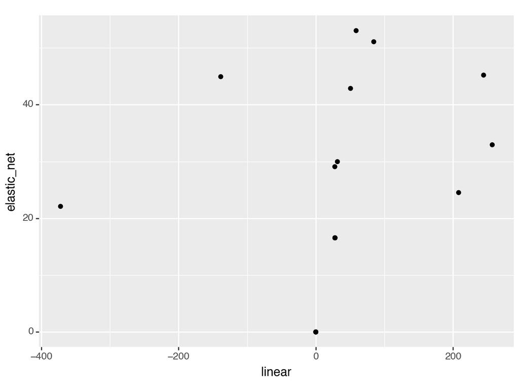

```
<Figure Size: (640 x 480)>
```

```python
#plot comparing coefficients between best model (elastic net) and linear model with the 5 numerical var + division

coefficient_df = pd.DataFrame({"linear": coeff_lr_inter,
                               "elastic_net": coeff_en_inter})
(ggplot(coefficient_df, aes(x = "linear", y = "elastic_net")) + geom_point())
```